# Trabajo Final R

Juan Carlos Aguirre

November 25, 2019

# Expresiones Regulares

Las expresiones regulares (abreviadas como “expresiones regulares”) son cadenas especiales que representan un patrón para que coincida en una operación de búsqueda. Son una herramienta importante en una amplia variedad de aplicaciones informáticas, desde lenguajes de programación como Java y Perl, hasta herramientas de procesamiento de texto como grep, sed y el editor de texto vim.

En el siguente enlace puedes encontrar un cheat sheet que puede ayudar a utlizar lo basico de las expresiones regulares. [Tabla para R](https://rstudio.com/wp-content/uploads/2016/09/RegExCheatsheet.pdf)

> *Tuve algunas dudas sobre la filosofía porque,si elaborabas una teoría filosófica,era difícil saber si ibas a poder probarla o si otras teorías tenían tan buena pretensión de creencia.*

# Pagina de Expresiones Regulares

Me parece que en esta primer [pagina web](https://www.adictosaltrabajo.com/2015/01/29/regexsam/), tiene muy bueno contenido debido a la foma de presentar en la cual te lleva con una pequena introduccion, te muestra la sintaxis y las formas en la que debes de trabajar con las expresiones.

### Puntos Fuertes

Los puntos fuertes de la primer pagina a mi gusto son:

1. La interfaz muy intuitiva y limpia a la ves.
2. Facil de seguir la explicacion de las expresiones.
3. Te brinda varios enlaces para poder ver los ejemplos.
4. Podria ser un buen tutorial para principiantes.

### Puntos Debiles

Aspectos que no me agradaron de la pagina, fue que uno de los enlaces no esta funcionando, pero en terminos generales me parecio una buena pagina completa.

# Segunda Pagina Expersiones Regualares

En esta segundo [Pagina Web](https://eldesvandejose.com/2017/08/18/expresiones-regulares-general/), no encontramos con algo muy diferente a la primera dado que para mi gusto, esta muy cargada y no se termina de entender mucho la finalidad de ella.

### Puntos Furtes

Como puntos fuertes la verdad que no pude encontarle nada, talves la facilidad para poder descargar la informacion en cualquier formato de manera rapida.

### Puntos Debiles

Los puntos debiles de la pagina son:

1. Muy cargada de informacion.
2. Los colores en los cuales se ponen la explicacion son muy fuertes.
3. No cuenta con muchos ejemplos de como utilizar las expresiones.
4. Carece de enlaces que la primera pagina contenia varios.

# Markdown

Markdown es un lenguaje de marcado ligero con sintaxis de formato de texto sin formato. Su diseño le permite convertirse a muchos formatos de salida, pero la herramienta original con el mismo nombre solo admite HTML. Markdown se usa a menudo para formatear archivos Readme, para escribir mensajes en foros de discusión en línea y para crear texto enriquecido utilizando un editor de texto sin formato.

# Video 1 Markdown

[figure not shown]

En el siguiente video es el primero en la comparativa y me parece que explica muy bien la forma de utilizar el markdown da muy buenos ejemplos y creo que se desenvuelve bien a la forma de explicar dicho video.

### Puntos Fuertes

Muy video explicando la aplicacion de Rmarkdown, explica muy bien y te muestra otros enlaces a otras paginas donde podriamos, buscar mas informacion si asi lo deseramos.

### Puntos Negativos

El audio del video me parece que no es tan optimo. Intervencion de otras personas en algunas partes del video ajenas a la explicacion.

# Video 2 Markadown

[figure not shown]

Me parece que el video esta bien en terminos generales, pero creo que no explica ciertas cosas, que en el video anterior si abarca.

### Puntos Fuertes

El audio me parece que es optimo, para poder entender mejor el video que a diferencia del otro no se escuchaba muy bien.

### Puntos Negativos

No muestra ciertos contenidos que me gustaria que abarcara. Me parece que es muy corto para abarcar un tema que se puede extender mucho.

# Graficos

### ggplot2

En es siguiente grafico analizamos la libreria de Chicken Weight, y comparamos como se comporta la dieta de los animales, con el tiempo y su peso

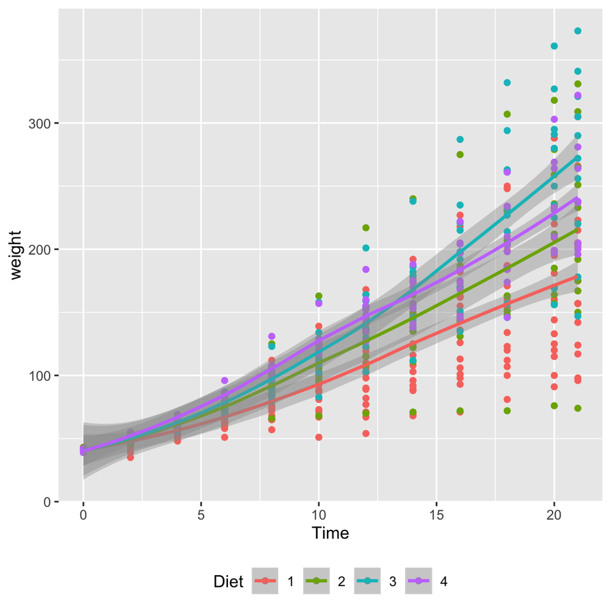

Time vs Weight, coloreado por Tipo de Dieta

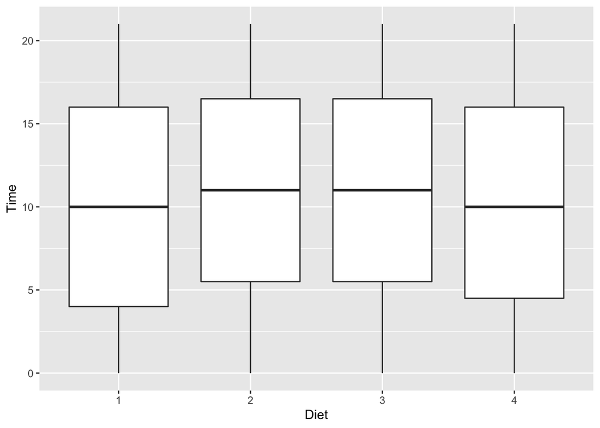

Otro grafico de Dieta vs Tiempo.

# Tabla

Tabla completa de los datos mtcars interactiva, donde se podra observar todos los datos que se encuentran en el datatable y poder buscarlos informacion, decidir cuantos elementos quieres que se muestren en tu data.

|  | mpg | cyl | disp | hp | drat | wt | qsec | vs | am | gear | carb |
| --- | --- | --- | --- | --- | --- | --- | --- | --- | --- | --- | --- |
| Mazda RX4 | 21 | 6 | 160 | 110 | 3.9 | 2.62 | 16.46 | 0 | 1 | 4 | 4 |
| Mazda RX4 Wag | 21 | 6 | 160 | 110 | 3.9 | 2.875 | 17.02 | 0 | 1 | 4 | 4 |
| Datsun 710 | 22.8 | 4 | 108 | 93 | 3.85 | 2.32 | 18.61 | 1 | 1 | 4 | 1 |
| Hornet 4 Drive | 21.4 | 6 | 258 | 110 | 3.08 | 3.215 | 19.44 | 1 | 0 | 3 | 1 |
| Hornet Sportabout | 18.7 | 8 | 360 | 175 | 3.15 | 3.44 | 17.02 | 0 | 0 | 3 | 2 |
| Valiant | 18.1 | 6 | 225 | 105 | 2.76 | 3.46 | 20.22 | 1 | 0 | 3 | 1 |
| Duster 360 | 14.3 | 8 | 360 | 245 | 3.21 | 3.57 | 15.84 | 0 | 0 | 3 | 4 |
| Merc 240D | 24.4 | 4 | 146.7 | 62 | 3.69 | 3.19 | 20 | 1 | 0 | 4 | 2 |
| Merc 230 | 22.8 | 4 | 140.8 | 95 | 3.92 | 3.15 | 22.9 | 1 | 0 | 4 | 2 |
| Merc 280 | 19.2 | 6 | 167.6 | 123 | 3.92 | 3.44 | 18.3 | 1 | 0 | 4 | 4 |

[output cut: 22 more lines]